# Macro-Driven Cross-Asset Risk Analysis

### Gold (GC=F) · US Dollar Index (DXY) · US 10Y Treasury Yield

Author: Yurou Chen  
Date: February 2026

This report investigates cross-asset relationships between Gold, the US Dollar Index (DXY), and US 10Y Treasury yields using time-series analysis from 2020 to 2026.

The objective is to evaluate:

- Correlation dynamics
- Volatility regimes
- Risk-adjusted performance
- Drawdown characteristics
- Macro-hedging properties

# Executive Summary

Key findings:

• Gold exhibits persistent negative correlation with DXY (~ -0.38).  
• 60-day rolling correlation strengthened to approximately -0.45 in early 2026.  
• Gold displays higher short-term volatility (~3%) compared to DXY (~0.4%).  
• Gold delivered superior risk-adjusted returns (Sharpe ≈ 1.19).  
• US10Y experienced significantly deeper drawdowns (~ -73%).

These results confirm Gold’s macro-sensitive nature and partial hedge characteristics against USD strength.

# Executive Summary

Key findings:

• Gold exhibits persistent negative correlation with DXY (~ -0.38).  
• 60-day rolling correlation strengthened to approximately -0.45 in early 2026.  
• Gold displays higher short-term volatility (~3%) compared to DXY (~0.4%).  
• Gold delivered superior risk-adjusted returns (Sharpe ≈ 1.19).  
• US10Y experienced significantly deeper drawdowns (~ -73%).

These results confirm Gold’s macro-sensitive nature and partial hedge characteristics against USD strength.

| Date | GOLD | DXY | US10Y |
| --- | --- | --- | --- |
| 2020-01-02 | 1524.500000 | 96.849998 | 1.882 |
| 2020-01-03 | 1549.199951 | 96.839996 | 1.788 |
| 2020-01-06 | 1566.199951 | 96.669998 | 1.811 |
| 2020-01-07 | 1571.800049 | 96.980003 | 1.827 |
| 2020-01-08 | 1557.400024 | 97.300003 | 1.874 |

|  | GOLD | DXY | US10Y |
| --- | --- | --- | --- |
| GOLD | 1.000000 | -0.382023 | -0.187149 |
| DXY | -0.382023 | 1.000000 | 0.221255 |
| US10Y | -0.187149 | 0.221255 | 1.000000 |

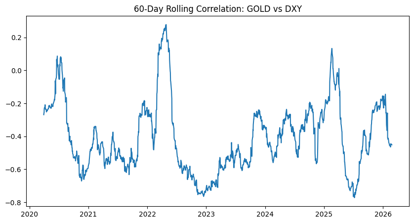

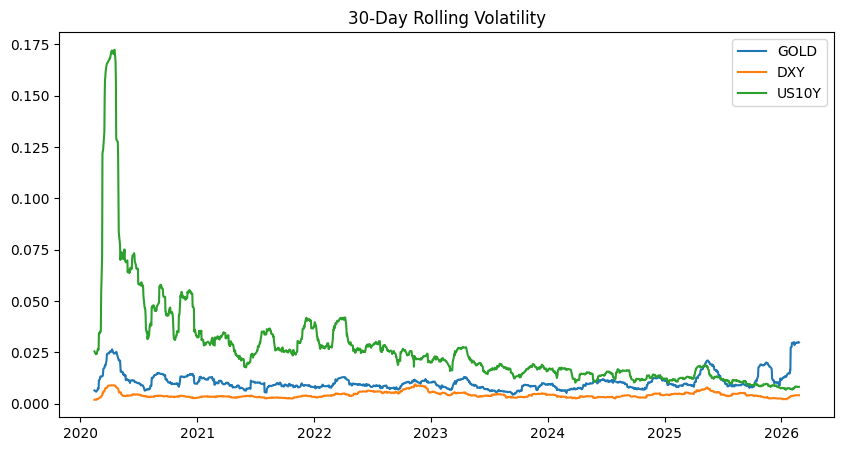

|  | AnnualReturn | AnnualVol | Sharpe | MaxDrawdown |
| --- | --- | --- | --- | --- |
| GOLD | 0.217147 | 0.181690 | 1.195149 | -0.208725 |
| DXY | 0.003772 | 0.070731 | 0.053328 | -0.156779 |
| US10Y | 0.281470 | 0.567100 | 0.496332 | -0.733725 |

# Interpretation

Gold maintains a structurally negative relationship with the US Dollar Index.

During periods of intensified USD strength, gold prices tend to face downward pressure.

Rolling analysis reveals regime-dependent variation in correlation intensity, particularly visible in early 2026.

Despite higher volatility, gold delivered superior risk-adjusted returns, suggesting compensation for elevated risk exposure.

US10Y displayed significant drawdown risk, highlighting duration sensitivity during stress environments.

```
(np.float64(0.0007746135204523024), np.float64(0.0009377353284682974))
```

# Volatility Regime Insight

Gold demonstrates different return behavior across volatility regimes.

High-volatility periods often coincide with macro stress environments, reinforcing gold’s defensive characteristics.

# Conclusion

This cross-asset analysis confirms gold’s macro-driven sensitivity and partial hedge properties.

While exhibiting higher short-term volatility, gold delivered stronger risk-adjusted performance relative to DXY and US10Y.

These findings reinforce gold’s relevance in diversified macro portfolios.